# AKSSF Temperature Data Summary

Document last updated 2022-02-22 22:24:34 by Rebecca Shaftel (rsshaftel@alaska.edu).

This is a summary of the stream temperature dataset that we will are using the AKSSF Stream Thermal Sensitivity project.

We had a team meeting on January 25, 2021 and there were several things we discussed.

- We have included several additional datasets, including those recommended by Luca for the Copper River watershed and additional data from Kodiak.
- For daymet, air temperatures were extracted by site location. Daymet are on a 1 km grid. They have not been processed by catchment because the daymet netcdf subset service was down from mid-May until June 10 when I was working on this. I further investigated the sizes of our catchments and realized they are mostly < 1 km<sup>2</sup> so it doesn’t make sense to aggregate at that spatial scale.
- There was some discussion during our first meeting regarding whether or how much of September to include in the analysis. I have created some data summaries showing the sample size after filtering on end dates of Aug. 31, Sept. 15, and Sept. 30 and completeness values of 70%, 80%, and 90% (number of days within the summer window).
- Part of the September discussion included whether air temperatures were below zero towards the end of that month. I plotted the air-stream temperatures by month and region to visualize those ranges and patterns and also made a table looking at which days were below zero.
- Since DFA will be run by year, I summarized the number of sites by each year to see if there is a start year we should use or some years where data are too limited to include in the analysis.
- We also talked about an interest in exploring the response to 2019 in particular so I have created some plots showing data by region for that year.

Decisions to prepare data for the DFA.

1. Do we want the daymet air temperatures summarized over catchments or sites?
2. What should be use for our end date in the summer window?
3. How much missing data can DFA handle within a time series? Should we filter on 70%, 80%, or 90% completeness?
4. Are there a specific set of years we want to focus on?
5. Anything else I am missing that should be considered before running the DFA?

# Map of sites and years of data

This map shows the location of all of the sites that we have data for. Selecting each marker will show the data provider, the site name, the river name, the start year, the end year, and the number of years of data.

```r
sumdat <- readRDS("data_preparation/final_data/archive/summer_data_wair2021-07-30.rds")
md <- read_rds("data_preparation/final_data/archive/md.rds")

md_sf <- st_as_sf(md, coords = c("Longitude", "Latitude"), crs = "wgs84")

map.dat <- sumdat %>%
  distinct(SiteID, year = year(sampleDate)) %>%
  group_by(SiteID) %>%
  summarize(start_year = min(year),
            end_year = max(year),
            total_years = n()) %>%
  arrange(SiteID)

md_sf <- merge(md_sf, map.dat)
```

```r
# create map
leaflet() %>%
  addTiles() %>%  # Add default OpenStreetMap map tiles
  #fitBounds(-150, 60.04,-149.0, 60.02) %>%
  #setView(-150.210169, 60.487694, zoom = 8) %>%
  addMarkers(lng = map.dat$Longitude, lat = map.dat$Latitude,
             popup = paste("SiteID = ", map.dat$SiteID, "<br>",
                           "Waterbody = ", map.dat$Waterbody_name, "<br>",
                           "Data Source = ", map.dat$SourceName, "<br>",
                           "Start Year = ", map.dat$startYear, "<br>",
                           "End Year = ", map.dat$endYear, "<br>",
                           "Total Years of Data = ", map.dat$totYears, "<br>"))
```

```r
tmap_mode("view")

sitemap <- md_sf %>%
  tm_shape() +
  tm_dots(id = "SiteID", size = 0.05, group = "Sites", col = "SourceName",
          popup.vars = c("Waterbody_name", "start_year", "end_year", "total_years")) +
  tm_text("SiteID", size = 1.5, shadow = TRUE, auto.placement = TRUE,
          just = "bottom", remove.overlap = TRUE, clustering = TRUE, group = "Labels" ) +
  tm_basemap(server = c(Topo = "Esri.WorldTopoMap", Imagery = "Esri.WorldImagery" ))

sitemap
```

[interactive chart not shown]

# Catchment air temperatures

Note: the previous comparison between catchment and site air temperatures was already smoothed over a moving window so it wasn’t an accurate comparison. I re-extracted catchment temperatures for three catchments in the Anchor and they came out the same as site air temperatures because the catchments were smaller than 1 km<sup>2</sup>, the daymet cell size.

Catchments are quite small in both the NHDPlus and our synthetic networks so there isn’t a good reason to take an average over the catchment.

```r
cats_ci <- st_read(dsn = "T:/Aquatic/AKSSF/AKSSF_Hydrography.gdb", layer = "NHDPlusCatchments_CookInlet_Merge")

st_area(cats_ci) %>%
  as_tibble() %>%
  mutate(km2 = as.numeric(value)/1000000) %>%
  summary() %>%
  kable(caption = "Summary of catchment sizes for Cook Inlet NHDPlus")
```

[output not shown]

Other options would be to summarize by watershed, but I don’t think there would a good explanatory power between air temperatures over large watersheds and stream temperatures. Or, a moving window (e.g. 3x3 cells). The downside to that approach would be extracting air temperatures from cells that don’t drain to the site locations.

# Summer window and completeness

```r
#get huc8, region, and waterbody name on the data.

sumdat <- left_join(sumdat, md %>% select(SiteID, Waterbody_name, Name:Region))

sumtbl <- sumdat %>%
  mutate(year = year(sampleDate),
         jd = format(sampleDate, "%j"),
         S30 = case_when(jd < 274 ~ 1,
                         TRUE ~ 0),
         S15 = case_when(jd < 259 ~ 1,
                         TRUE ~ 0),
         A31 = case_when(jd < 244 ~ 1,
                         TRUE ~ 0)) %>%
  group_by(Region, SiteID, Waterbody_name, year) %>%
  summarize("Sept. 30" = sum(S30 == 1)/122,
            "Sept. 15" = sum(S15 == 1)/107,
            "Aug. 31" = sum(A31 == 1)/92) %>%
  ungroup() %>%
  pivot_longer(cols = 'Sept. 30':'Aug. 31', names_to = "Window", values_to = "value")
```

Table showing the number of time series (site and year combinations) with data completeness in each of three windows, all starting June 1. Window indicates the end date and the columns indicate the percent of days with data within the summer window (e.g. June 1 - September 30).

```r
sumtbl %>%
  group_by(Window) %>%
  summarize("70%" = sum(value > 0.7),
            "80%" = sum(value > 0.8),
            "90%" = sum(value > 0.9))
```

| Window | 70% | 80% | 90% |
| --- | --- | --- | --- |
| Aug. 31 | 1970 | 1855 | 1644 |
| Sept. 15 | 1941 | 1803 | 1552 |
| Sept. 30 | 1857 | 1639 | 1370 |

# Air-stream relationships by month

These are plots of the daily air temperatures and stream temperatures by month and region. There is obviously a lot of sites that have very cold stream temperatures with little response to air temperatures. There are some air temperatures below zero, especially in the Copper River watershed and also in Cook Inlet.

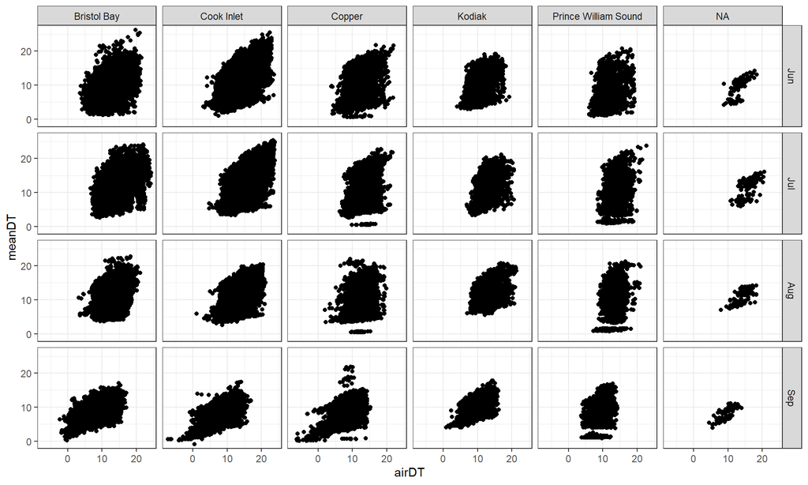

```r
sumdat %>%
  mutate(month = month(sampleDate, label = TRUE)) %>%
  ggplot() +
  geom_point(aes(y = meanDT, x = airDT)) +
  facet_grid(cols = vars(Region), rows = vars(month)) +
  theme_bw()
```

Table showing number of days with air temperatures below zero by month and day. Almost everything is after September 20, so cutting the data off at September 15 seems to make sense.

```r
sumdat %>%
  filter(airDT < 0) %>%
  mutate(day = format(sampleDate, "%m-%d")) %>%
  count(day) %>%
  arrange(day)
```

| day | n |
| --- | --- |
| 09-02 | 1 |
| 09-03 | 1 |
| 09-20 | 2 |
| 09-21 | 3 |
| 09-22 | 3 |
| 09-23 | 15 |
| 09-24 | 17 |
| 09-25 | 11 |
| 09-26 | 8 |
| 09-27 | 20 |

[output cut: 3 more lines]

# Data summary by year

Function to filter data frame by different combinations of julian date and completeness. Note this assumes a lot about the input data frame.

```r
jd_completeness_filter <- function(inputDat, jd_filter, completeness_filter) {
  dat <- inputDat %>%
    mutate(jd = as.numeric(format(sampleDate, "%j")),
           year = year(sampleDate)) %>%
    filter(jd >= 152, jd <= jd_filter) #June 1st to end date
  ndays <- max(dat$jd) - min(dat$jd)
  dat2 <- dat %>%
    group_by(SiteID, year) %>%
    mutate(completeness = n()/ndays * 100) %>%
    filter(completeness > completeness_filter) %>%
    ungroup()
  return(dat2)
}
```

Filter on September 15 as an end date and 70% of days within summer window.

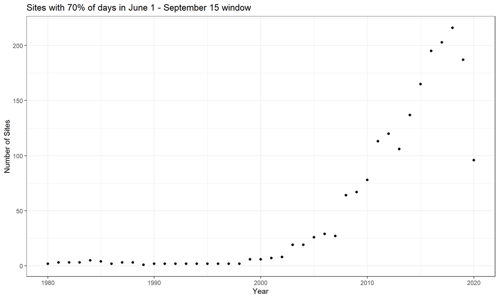

```r
sumdat2 <- jd_completeness_filter(sumdat, 258, 70)

sumdat2 %>%
  distinct(SiteID, year) %>%
  count(year) %>%
  ggplot() +
  geom_point(aes(x = year, y = n)) +
  labs(x = "Year", y = "Number of Sites", title = "Sites with 70% of days in June 1 - September 15 window") +
  theme_bw()
```

Look at number of sites by region and year using 8/31 end date and 80% completeness as the data filter. (This was discussed during a meeting on 8/17/21.)

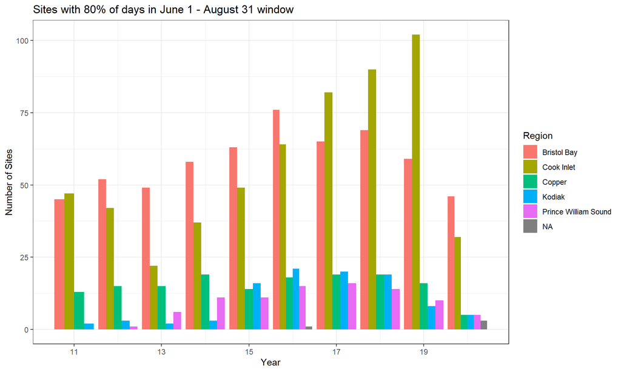

```r
sumdat3 <- jd_completeness_filter(sumdat, 243, 80)

sumdat3 <- left_join(sumdat3, md %>% select(SiteID, Region))

sumdat3 %>%
  distinct(Region, SiteID, year) %>%
  count(Region, year) %>%
  filter(year %in% c(2011:2020)) %>%
  ggplot() +
  geom_col(aes(x = year, y = n, fill = Region), position = position_dodge()) +
  labs(x = "Year", y = "Number of Sites", title = "Sites with 80% of days in June 1 - August 31 window") +
  theme_bw() +
  scale_x_continuous(breaks = c(2011, 2013, 2015, 2017, 2019),
                     labels = c("11", "13", "15", "17", "19"))
```

# Patterns in 2019

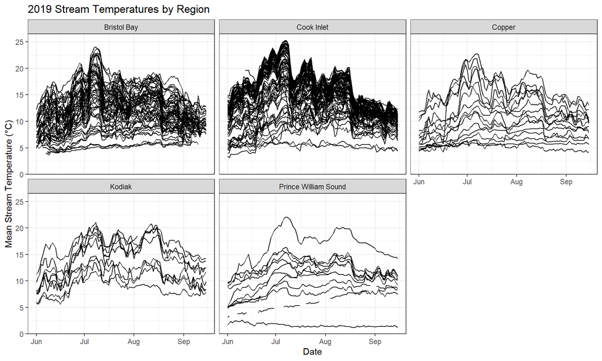

```r
sumdat2 %>%
  filter(year == 2019) %>%
  complete(Region, SiteID, sampleDate = seq.Date(min(sampleDate), max(sampleDate), by = "day")) %>%
  ggplot(aes(x = sampleDate, y = meanDT, group = SiteID)) +
  geom_line() +
  facet_wrap(~Region) +
  labs(x = "Date", y = "Mean Stream Temperature (°C)", title = "2019 Stream Temperatures by Region") +
  theme_bw()
```

# Differences in maximum water temperatures

```r
sumdat3 %>%
  count(Region, SiteID, year) %>%
  nrow()
```

```
## [1] 1871
```

```r
sumdat3 %>% distinct(Region, SiteID) %>% count(Region)
```

| Region | n |
| --- | --- |
| Bristol Bay | 120 |
| Cook Inlet | 225 |
| Copper | 29 |
| Kodiak | 31 |
| Prince William Sound | 22 |
| NA | 3 |

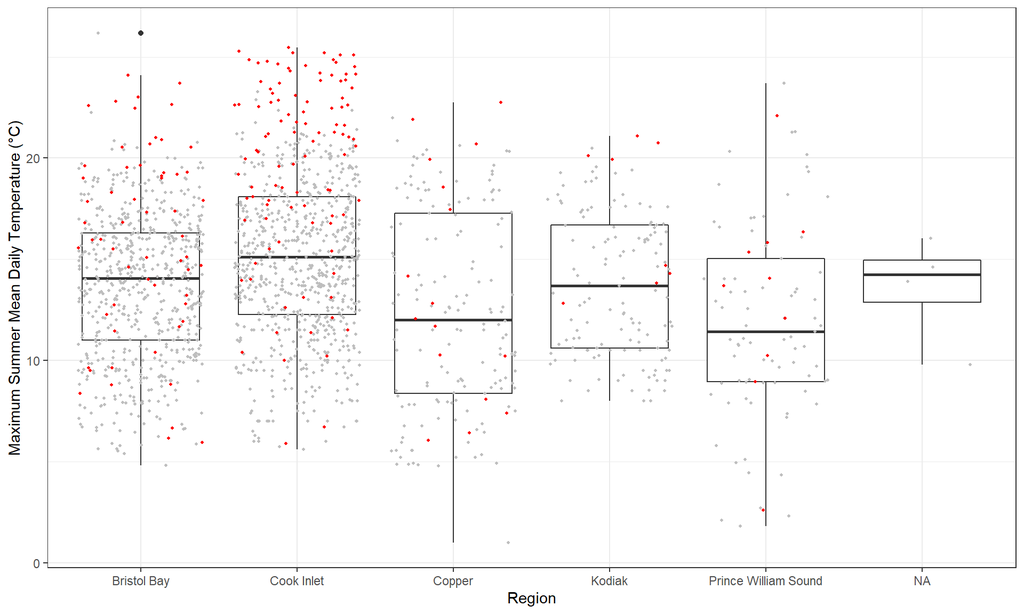

```r
sumdat3 %>%
  group_by(Region, SiteID, year) %>%
  summarize(max_daily = max(meanDT)) %>%
  ggplot() +
  geom_boxplot(aes(x = Region, y = max_daily)) +
  geom_jitter(data = . %>% filter(!year == 2019), aes(x = Region, y = max_daily), color = "grey", size = 0.7) +
  geom_jitter(data = . %>% filter(year == 2019), aes(x = Region, y = max_daily), color = "red", size = 0.7) +
  # geom_jitter(data = . %>% filter(SiteID %in% c("CIK_28", "Deshka 6 Downstream", "Deshka 6 Upstream")),
  #             aes(x = Region, y = max_daily), shape = 2) +
  theme_bw() +
  labs(y = "Maximum Summer Mean Daily Temperature (°C)")
```

```r
ggsave("output/boxplot of max temps by region.jpeg")
```